# ANOVA,MANOVA, and Posthoc

### Visualization

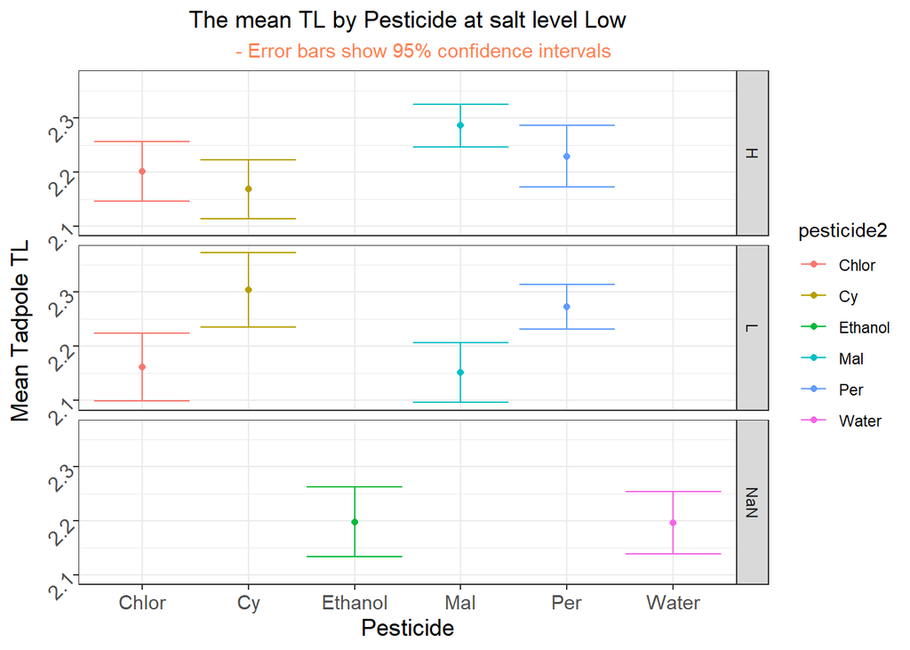

```r
TL_exp2 = Exp2_SaltL%>%
  group_by(pesticidecon,pesticide2)%>%
  summarise(count = n(),  #  calculate count, mean, and sd in each group
             mean = mean(tl,na.rm=TRUE),
             std_dev = sd(tl,na.rm =TRUE ))%>%
   mutate(std_error = std_dev / sqrt(count),  #  add standard error of each mean
         lower = mean - 1.96 * std_error,  #  compute lower bound
          upper = mean + 1.96 * std_error)


ggplot(TL_exp2,aes(x=pesticide2,y=mean,col=pesticide2))+
  geom_point()+
  geom_errorbar(aes(ymin = lower,
                    ymax=upper))+
  labs(x="Pesticide",
       y="Mean Tadpole TL ",
       title = "The mean TL by Pesticide at salt level Low",
       subtitle = "      - Error bars show 95% confidence intervals")+
  my_theme+
  facet_grid(pesticidecon~.)
```

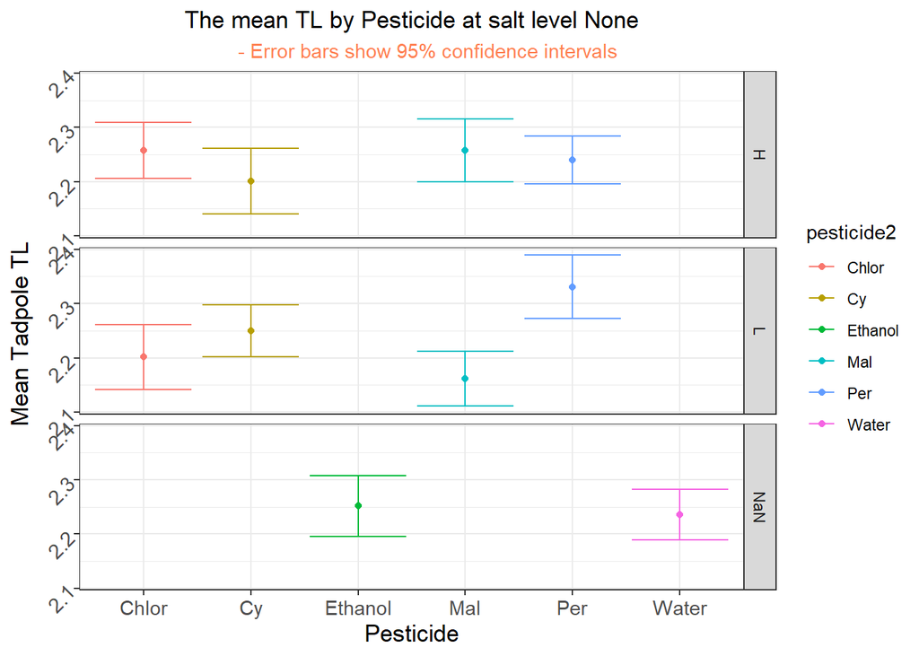

```r
TL_exp2 = Exp2_SaltN%>%
  group_by(pesticidecon,pesticide2)%>%
  summarise(count = n(),  #  calculate count, mean, and sd in each group
             mean = mean(tl,na.rm=TRUE),
             std_dev = sd(tl,na.rm =TRUE ))%>%
   mutate(std_error = std_dev / sqrt(count),  #  add standard error of each mean
         lower = mean - 1.96 * std_error,  #  compute lower bound
          upper = mean + 1.96 * std_error)


ggplot(TL_exp2,aes(x=pesticide2,y=mean,col=pesticide2))+
  geom_point()+
  geom_errorbar(aes(ymin = lower,
                    ymax=upper))+
  labs(x="Pesticide",
       y="Mean Tadpole TL ",
       title = "The mean TL by Pesticide at salt level None",
       subtitle = "      - Error bars show 95% confidence intervals")+
  my_theme+
  facet_grid(pesticidecon~.)
```

### Three way ANOVA for OTW

```r
experiment2%>%
  anova_test(otw~pesticide2 * pesticidecon*salt)
```

```
## ANOVA Table (type II tests)
##
##                         Effect DFn DFd      F        p p<.05   ges
## 1                   pesticide2   4 996  2.682 3.00e-02     * 0.011
## 2                 pesticidecon   1 996  7.074 8.00e-03     * 0.007
## 3                         salt   2 996 10.264 3.87e-05     * 0.020
## 4      pesticide2:pesticidecon   3 996  2.617 5.00e-02     * 0.008
## 5              pesticide2:salt   8 996  2.300 1.90e-02     * 0.018
## 6            pesticidecon:salt   2 996  2.102 1.23e-01       0.004
## 7 pesticide2:pesticidecon:salt   6 996  2.502 2.10e-02     * 0.015
```

Interaction is significant

```r
experiment2%>%
  group_by(salt)%>%
  anova_test(otw~pesticide2*pesticidecon)%>%
  pander()
```

| salt | Effect | DFn | DFd | F | p | p<.05 | ges |
| --- | --- | --- | --- | --- | --- | --- | --- |
| H | pesticide2 | 4 | 350 | 1.735 | 0.142 |  | 0.019 |
| H | pesticidecon | 1 | 350 | 2.14 | 0.144 |  | 0.006 |
| H | pesticide2:pesticidecon | 3 | 350 | 0.815 | 0.486 |  | 0.007 |
| L | pesticide2 | 4 | 342 | 2.572 | 0.038 | * | 0.029 |
| L | pesticidecon | 1 | 342 | 0.032 | 0.858 |  | 9.32e-05 |
| L | pesticide2:pesticidecon | 3 | 342 | 2.565 | 0.055 |  | 0.022 |
| N | pesticide2 | 4 | 304 | 3.324 | 0.011 | * | 0.042 |
| N | pesticidecon | 1 | 304 | 9.913 | 0.002 | * | 0.032 |
| N | pesticide2:pesticidecon | 3 | 304 | 4.558 | 0.004 | * | 0.043 |

This chunk performed a two way on pesticide category in terms of mean OTW by each salt level.

```r
Tukey_SL = experiment2%>%
  group_by(salt,pesticidecon)%>%
  tukey_hsd(otw~pesticide2)

Tukey_SN=Tukey_SL%>%filter(salt=="N")

Tukey_SN[which(Tukey_SN$p.adj<=0.05),]%>%
  pander()
```

Table continues below

| pesticidecon | salt | term | group1 | group2 | estimate | conf.low |
| --- | --- | --- | --- | --- | --- | --- |
| L | N | pesticide2 | Cy | Mal | -0.1788 | -0.3271 |
| NaN | N | pesticide2 | Ethanol | Water | -0.2006 | -0.3112 |

| conf.high | p.adj | p.adj.signif |
| --- | --- | --- |
| -0.03044 | 0.0112 | * |
| -0.09004 | 0.000621 | *** |

This chunk performed a Tukey-test on pesticide category in terms of mean OTW by each concentration level and salt level. The pairs with p-value <= 0.05 are shown. (I did not write down the ANOVA test because a non-empty result from tukey test implies a statistically significant result in the one way ANOVA test)

### Visualization

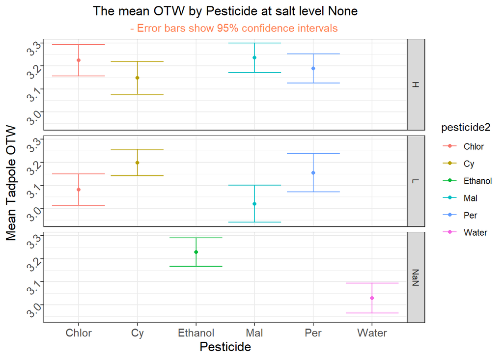

```r
OTW_exp2 = Exp2_SaltN%>%
  group_by(pesticidecon,pesticide2)%>%
  summarise(count = n(),  #  calculate count, mean, and sd in each group
             mean = mean(otw,na.rm=TRUE),
             std_dev = sd(otw,na.rm =TRUE ))%>%
   mutate(std_error = std_dev / sqrt(count),  #  add standard error of each mean
         lower = mean - 1.96 * std_error,  #  compute lower bound
          upper = mean + 1.96 * std_error)


ggplot(OTW_exp2,aes(x=pesticide2,y=mean,col=pesticide2))+
  geom_point()+
  geom_errorbar(aes(ymin = lower,
                    ymax=upper))+
  labs(x="Pesticide",
       y="Mean Tadpole OTW ",
       title = "The mean OTW by Pesticide at salt level None",
       subtitle = "      - Error bars show 95% confidence intervals")+
  my_theme+
  facet_grid(pesticidecon~.)
```

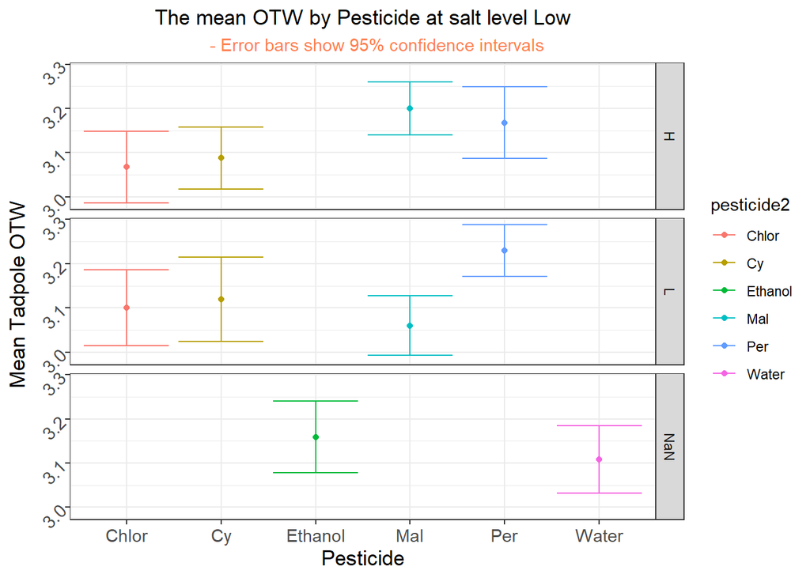

```r
OTW_exp2 = Exp2_SaltL%>%
  group_by(pesticidecon,pesticide2)%>%
  summarise(count = n(),  #  calculate count, mean, and sd in each group
             mean = mean(otw,na.rm=TRUE),
             std_dev = sd(otw,na.rm =TRUE ))%>%
   mutate(std_error = std_dev / sqrt(count),  #  add standard error of each mean
         lower = mean - 1.96 * std_error,  #  compute lower bound
          upper = mean + 1.96 * std_error)


ggplot(OTW_exp2,aes(x=pesticide2,y=mean,col=pesticide2))+
  geom_point()+
  geom_errorbar(aes(ymin = lower,
                    ymax=upper))+
  labs(x="Pesticide",
       y="Mean Tadpole OTW ",
       title = "The mean OTW by Pesticide at salt level Low",
       subtitle = "      - Error bars show 95% confidence intervals")+
  my_theme+
  facet_grid(pesticidecon~.)
```

### Three way ANOVA for OTL

```r
experiment2%>%
  anova_test(otl~pesticide2 * pesticidecon*salt)
```

```
## ANOVA Table (type II tests)
##
##                         Effect DFn DFd      F        p p<.05      ges
## 1                   pesticide2   4 986  1.402 2.31e-01       0.006000
## 2                 pesticidecon   1 986  0.753 3.86e-01       0.000764
## 3                         salt   2 986 22.229 3.61e-10     * 0.043000
## 4      pesticide2:pesticidecon   3 986  0.255 8.58e-01       0.000775
## 5              pesticide2:salt   8 986  1.886 5.90e-02       0.015000
## 6            pesticidecon:salt   2 986  0.553 5.76e-01       0.001000
## 7 pesticide2:pesticidecon:salt   6 986  4.312 2.65e-04     * 0.026000
```

Interaction is significant

```r
experiment2%>%
  group_by(salt)%>%
  anova_test(otl~pesticide2*pesticidecon)%>%
  pander()
```

| salt | Effect | DFn | DFd | F | p | p<.05 | ges |
| --- | --- | --- | --- | --- | --- | --- | --- |
| H | pesticide2 | 4 | 348 | 0.303 | 0.876 |  | 0.003 |
| H | pesticidecon | 1 | 348 | 0.979 | 0.323 |  | 0.003 |
| H | pesticide2:pesticidecon | 3 | 348 | 4.262 | 0.006 | * | 0.035 |
| L | pesticide2 | 4 | 342 | 3.701 | 0.006 | * | 0.041 |
| L | pesticidecon | 1 | 342 | 0.144 | 0.704 |  | 0.000421 |
| L | pesticide2:pesticidecon | 3 | 342 | 1.82 | 0.143 |  | 0.016 |
| N | pesticide2 | 4 | 296 | 1.062 | 0.375 |  | 0.014 |
| N | pesticidecon | 1 | 296 | 0.928 | 0.336 |  | 0.003 |
| N | pesticide2:pesticidecon | 3 | 296 | 2.903 | 0.035 | * | 0.029 |

This chunk performed a two way ANOVA on pesticide category in terms of mean OTL by each salt level.

Interaction is significant on salt level H and level None

```r
Tukey_SL = experiment2%>%
  group_by(salt,pesticidecon)%>%
  tukey_hsd(otl~pesticide2)

Tukey_SN=Tukey_SL%>%filter(salt=="N")

Tukey_SN[which(Tukey_SN$p.adj<=0.05),]%>%
  pander()
```

Table continues below

| pesticidecon | salt | term | group1 | group2 | estimate | conf.low |
| --- | --- | --- | --- | --- | --- | --- |
| L | N | pesticide2 | Mal | Per | 0.1031 | 0.008224 |

| conf.high | p.adj | p.adj.signif |
| --- | --- | --- |
| 0.1979 | 0.0275 | * |

```r
Tukey_SH=Tukey_SL%>%filter(salt=="H")

Tukey_SH[which(Tukey_SN$p.adj<=0.05),]%>%
  pander()
```

Table continues below

| pesticidecon | salt | term | group1 | group2 | estimate | conf.low |
| --- | --- | --- | --- | --- | --- | --- |
| L | H | pesticide2 | Mal | Per | -0.103 | -0.2085 |

| conf.high | p.adj | p.adj.signif |
| --- | --- | --- |
| 0.002498 | 0.0584 | ns |

### Visualization

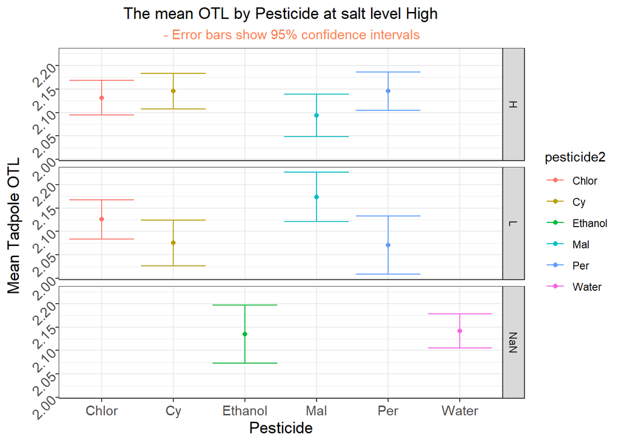

```r
OTL_exp2 = Exp2_SaltH%>%
  group_by(pesticidecon,pesticide2)%>%
  summarise(count = n(),  #  calculate count, mean, and sd in each group
             mean = mean(otl,na.rm=TRUE),
             std_dev = sd(otl,na.rm =TRUE ))%>%
   mutate(std_error = std_dev / sqrt(count),  #  add standard error of each mean
         lower = mean - 1.96 * std_error,  #  compute lower bound
          upper = mean + 1.96 * std_error)


ggplot(OTL_exp2,aes(x=pesticide2,y=mean,col=pesticide2))+
  geom_point()+
  geom_errorbar(aes(ymin = lower,
                    ymax=upper))+
  labs(x="Pesticide",
       y="Mean Tadpole OTL ",
       title = "The mean OTL by Pesticide at salt level High",
       subtitle = "      - Error bars show 95% confidence intervals")+
  my_theme+
  facet_grid(pesticidecon~.)
```

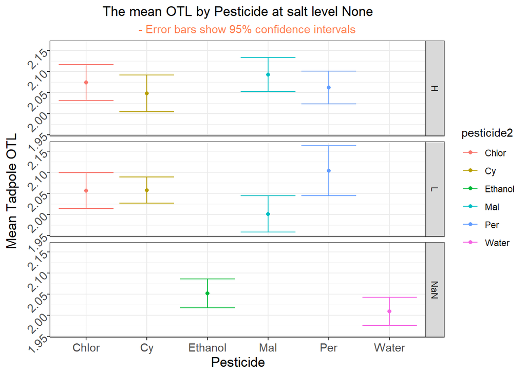

```r
OTL_exp2 = Exp2_SaltN%>%
  group_by(pesticidecon,pesticide2)%>%
  summarise(count = n(),  #  calculate count, mean, and sd in each group
             mean = mean(otl,na.rm=TRUE),
             std_dev = sd(otl,na.rm =TRUE ))%>%
   mutate(std_error = std_dev / sqrt(count),  #  add standard error of each mean
         lower = mean - 1.96 * std_error,  #  compute lower bound
          upper = mean + 1.96 * std_error)


ggplot(OTL_exp2,aes(x=pesticide2,y=mean,col=pesticide2))+
  geom_point()+
  geom_errorbar(aes(ymin = lower,
                    ymax=upper))+
  labs(x="Pesticide",
       y="Mean Tadpole OTL ",
       title = "The mean OTL by Pesticide at salt level None",
       subtitle = "      - Error bars show 95% confidence intervals")+
  my_theme+
  facet_grid(pesticidecon~.)
```

### Three way ANOVA for OBL

```r
experiment2%>%
  anova_test(obl~pesticide2 * pesticidecon*salt)
```

```
## ANOVA Table (type II tests)
##
##                         Effect DFn DFd     F        p p<.05      ges
## 1                   pesticide2   4 994 9.620 1.24e-07     * 0.037000
## 2                 pesticidecon   1 994 2.204 1.38e-01       0.002000
## 3                         salt   2 994 9.579 7.58e-05     * 0.019000
## 4      pesticide2:pesticidecon   3 994 7.181 9.02e-05     * 0.021000
## 5              pesticide2:salt   8 994 4.249 4.95e-05     * 0.033000
## 6            pesticidecon:salt   2 994 0.237 7.89e-01       0.000476
## 7 pesticide2:pesticidecon:salt   6 994 4.500 1.65e-04     * 0.026000
```

Interaction is significant

### Two way ANOVA for OBL

```r
experiment2%>%
  group_by(salt)%>%
  anova_test(obl~pesticide2*pesticidecon)%>%
  pander()
```

| salt | Effect | DFn | DFd | F | p | p<.05 | ges |
| --- | --- | --- | --- | --- | --- | --- | --- |
| H | pesticide2 | 4 | 349 | 11.72 | 6.04e-09 | * | 0.118 |
| H | pesticidecon | 1 | 349 | 0.043 | 0.836 |  | 0.000123 |
| H | pesticide2:pesticidecon | 3 | 349 | 3.968 | 0.008 | * | 0.033 |
| L | pesticide2 | 4 | 340 | 0.645 | 0.631 |  | 0.008 |
| L | pesticidecon | 1 | 340 | 1.474 | 0.225 |  | 0.004 |
| L | pesticide2:pesticidecon | 3 | 340 | 5.321 | 0.001 | * | 0.045 |
| N | pesticide2 | 4 | 305 | 6.04 | 0.000109 | * | 0.073 |
| N | pesticidecon | 1 | 305 | 1.461 | 0.228 |  | 0.005 |
| N | pesticide2:pesticidecon | 3 | 305 | 7.01 | 0.000142 | * | 0.065 |

This chunk performed a Two way ANOVA on pesticide category in terms of mean OBL by each salt level.

Interaction is significant on all level of salt

```r
Tukey_SL = experiment2%>%
  group_by(salt,pesticidecon)%>%
  tukey_hsd(obl~pesticide2)

Tukey_SL[which(Tukey_SL$p.adj<=0.05),]%>%
  pander()
```

Table continues below

| pesticidecon | salt | term | group1 | group2 | estimate | conf.low |
| --- | --- | --- | --- | --- | --- | --- |
| H | H | pesticide2 | Chlor | Mal | -0.09053 | -0.1454 |
| H | H | pesticide2 | Chlor | Per | -0.05725 | -0.1125 |
| L | H | pesticide2 | Chlor | Mal | -0.08241 | -0.1285 |
| L | H | pesticide2 | Cy | Mal | -0.1191 | -0.1625 |
| L | H | pesticide2 | Mal | Per | 0.0932 | 0.04786 |
| L | L | pesticide2 | Chlor | Mal | -0.05253 | -0.09944 |
| L | L | pesticide2 | Mal | Per | 0.07126 | 0.02405 |
| L | N | pesticide2 | Chlor | Cy | 0.1003 | 0.04863 |
| L | N | pesticide2 | Cy | Mal | -0.08748 | -0.1389 |
| L | N | pesticide2 | Cy | Per | -0.125 | -0.1825 |
| NaN | N | pesticide2 | Ethanol | Water | -0.05789 | -0.09411 |

| conf.high | p.adj | p.adj.signif |
| --- | --- | --- |
| -0.03563 | 0.000189 | *** |
| -0.001991 | 0.0392 | * |
| -0.03627 | 4.71e-05 | **** |
| -0.07565 | 3.42e-10 | **** |
| 0.1385 | 2.25e-06 | **** |
| -0.005619 | 0.0216 | * |
| 0.1185 | 0.000791 | *** |
| 0.152 | 8.61e-06 | **** |
| -0.0361 | 0.000116 | *** |
| -0.06747 | 5.66e-07 | **** |
| -0.02167 | 0.00227 | ** |

This chunk performed a Tukey-test on pesticide category in terms of mean OBL by each concentration level and salt level. The pairs with p-value <= 0.05 are shown. (I did not write down the ANOVA test because a non-empty result from tukey test implies a statistically significant result in the one way ANOVA test)

### Visualization for OBL

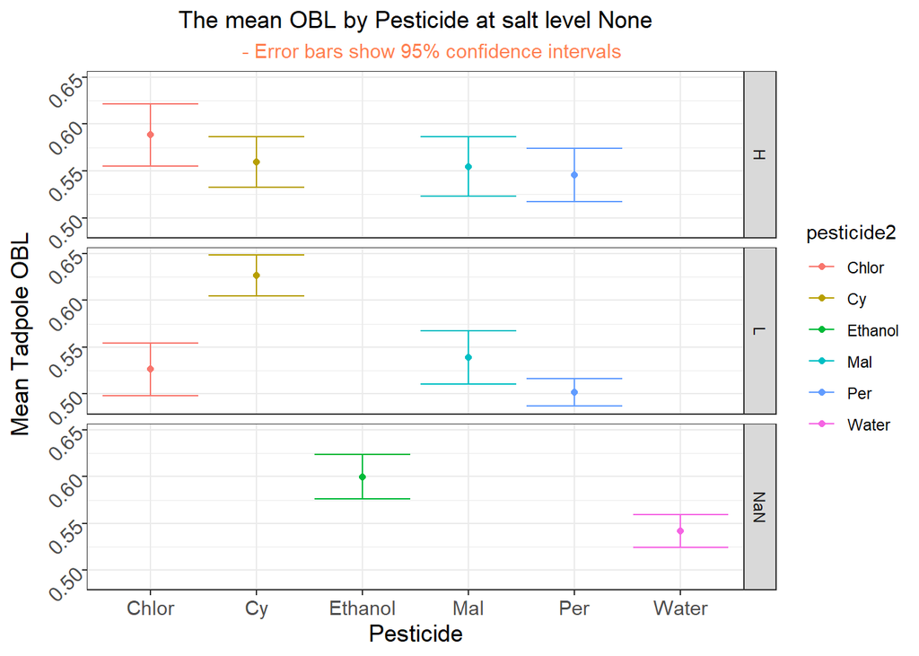

```r
OBL_exp2 = Exp2_SaltN%>%
  group_by(pesticidecon,pesticide2)%>%
  summarise(count = n(),  #  calculate count, mean, and sd in each group
             mean = mean(obl,na.rm=TRUE),
             std_dev = sd(obl,na.rm =TRUE ))%>%
   mutate(std_error = std_dev / sqrt(count),  #  add standard error of each mean
         lower = mean - 1.96 * std_error,  #  compute lower bound
          upper = mean + 1.96 * std_error)


ggplot(OBL_exp2,aes(x=pesticide2,y=mean,col=pesticide2))+
  geom_point()+
  geom_errorbar(aes(ymin = lower,
                    ymax=upper))+
  labs(x="Pesticide",
       y="Mean Tadpole OBL ",
       title = "The mean OBL by Pesticide at salt level None",
       subtitle = "      - Error bars show 95% confidence intervals")+
  my_theme+
  facet_grid(pesticidecon~.)
```

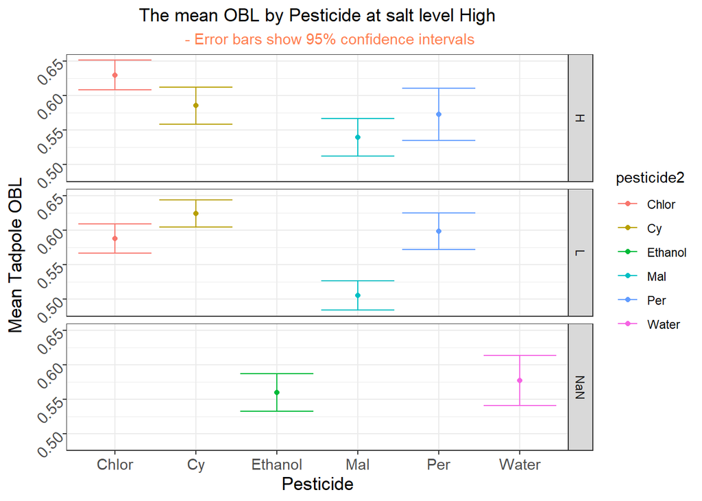

```r
OBL_exp2 = Exp2_SaltH%>%
  group_by(pesticidecon,pesticide2)%>%
  summarise(count = n(),  #  calculate count, mean, and sd in each group
             mean = mean(obl,na.rm=TRUE),
             std_dev = sd(obl,na.rm =TRUE ))%>%
   mutate(std_error = std_dev / sqrt(count),  #  add standard error of each mean
         lower = mean - 1.96 * std_error,  #  compute lower bound
          upper = mean + 1.96 * std_error)


ggplot(OBL_exp2,aes(x=pesticide2,y=mean,col=pesticide2))+
  geom_point()+
  geom_errorbar(aes(ymin = lower,
                    ymax=upper))+
  labs(x="Pesticide",
       y="Mean Tadpole OBL ",
       title = "The mean OBL by Pesticide at salt level High",
       subtitle = "      - Error bars show 95% confidence intervals")+
  my_theme+
  facet_grid(pesticidecon~.)
```

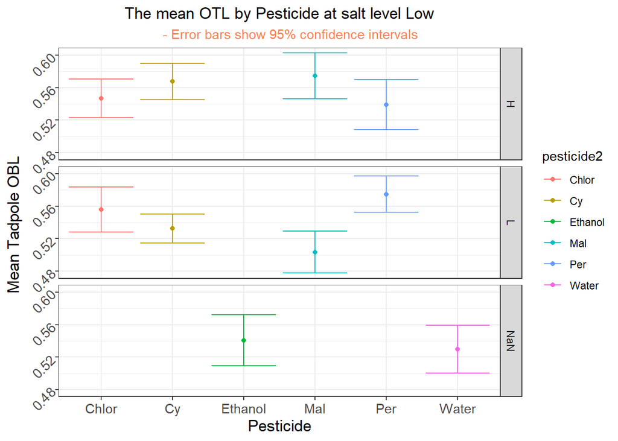

```r
OBL_exp2 = Exp2_SaltL%>%
  group_by(pesticidecon,pesticide2)%>%
  summarise(count = n(),  #  calculate count, mean, and sd in each group
             mean = mean(obl,na.rm=TRUE),
             std_dev = sd(obl,na.rm =TRUE ))%>%
   mutate(std_error = std_dev / sqrt(count),  #  add standard error of each mean
         lower = mean - 1.96 * std_error,  #  compute lower bound
          upper = mean + 1.96 * std_error)


ggplot(OBL_exp2,aes(x=pesticide2,y=mean,col=pesticide2))+
  geom_point()+
  geom_errorbar(aes(ymin = lower,
                    ymax=upper))+
  labs(x="Pesticide",
       y="Mean Tadpole OBL ",
       title = "The mean OTL by Pesticide at salt level Low",
       subtitle = "      - Error bars show 95% confidence intervals")+
  my_theme+
  facet_grid(pesticidecon~.)
```

### Three way ANOVA for DW

```r
experiment2%>%
  anova_test(dw~pesticide2 * pesticidecon*salt)
```

```
## ANOVA Table (type II tests)
##
##                         Effect DFn DFd      F        p p<.05   ges
## 1                   pesticide2   4 994  3.406 9.00e-03     * 0.014
## 2                 pesticidecon   1 994  1.262 2.62e-01       0.001
## 3                         salt   2 994 13.111 2.40e-06     * 0.026
## 4      pesticide2:pesticidecon   3 994  3.634 1.30e-02     * 0.011
## 5              pesticide2:salt   8 994  4.023 1.02e-04     * 0.031
## 6            pesticidecon:salt   2 994  0.674 5.10e-01       0.001
## 7 pesticide2:pesticidecon:salt   6 994  2.461 2.30e-02     * 0.015
```

Interaction is significant

```r
experiment2%>%
  group_by(salt)%>%
  anova_test(dw~pesticide2*pesticidecon)%>%
  pander()
```

| salt | Effect | DFn | DFd | F | p | p<.05 | ges |
| --- | --- | --- | --- | --- | --- | --- | --- |
| H | pesticide2 | 4 | 349 | 3.624 | 0.007 | * | 0.04 |
| H | pesticidecon | 1 | 349 | 0.134 | 0.715 |  | 0.000383 |
| H | pesticide2:pesticidecon | 3 | 349 | 0.508 | 0.677 |  | 0.004 |
| L | pesticide2 | 4 | 343 | 2.09 | 0.082 |  | 0.024 |
| L | pesticidecon | 1 | 343 | 0.002 | 0.964 |  | 5.81e-06 |
| L | pesticide2:pesticidecon | 3 | 343 | 5.282 | 0.001 | * | 0.044 |
| N | pesticide2 | 4 | 302 | 5.984 | 0.00012 | * | 0.073 |
| N | pesticidecon | 1 | 302 | 2.655 | 0.104 |  | 0.009 |
| N | pesticide2:pesticidecon | 3 | 302 | 3.244 | 0.022 | * | 0.031 |

This chunk performed a Two way on pesticide category in terms of mean DW by each salt level.

Interaction is significant on salt low and none

```r
Tukey_SL = experiment2%>%
  group_by(salt,pesticidecon)%>%
  tukey_hsd(dw~pesticide2)

Tukey_SLL=Tukey_SL%>%filter(salt=="L")

Tukey_SLL[which(Tukey_SLL$p.adj<=0.05),]%>%
  pander()
```

Table continues below

| pesticidecon | salt | term | group1 | group2 | estimate | conf.low |
| --- | --- | --- | --- | --- | --- | --- |
| H | L | pesticide2 | Chlor | Mal | 0.1193 | 0.03133 |
| L | L | pesticide2 | Mal | Per | 0.1118 | 0.02941 |

| conf.high | p.adj | p.adj.signif |
| --- | --- | --- |
| 0.2074 | 0.00318 | ** |
| 0.1942 | 0.00317 | ** |

```r
Tukey_SN=Tukey_SL%>%filter(salt=="N")

Tukey_SN[which(Tukey_SN$p.adj<=0.05),]%>%
  pander()
```

Table continues below

| pesticidecon | salt | term | group1 | group2 | estimate | conf.low |
| --- | --- | --- | --- | --- | --- | --- |
| NaN | N | pesticide2 | Ethanol | Water | -0.1647 | -0.2287 |

| conf.high | p.adj | p.adj.signif |
| --- | --- | --- |
| -0.1006 | 3.74e-06 | **** |

This chunk performed a Tukey-test on pesticide category in terms of mean DW by each concentration level and salt level. The pairs with p-value <= 0.05 are shown. (I did not write down the ANOVA test because a non-empty result from tukey test implies a statistically significant result in the one way ANOVA test)

### Visualization

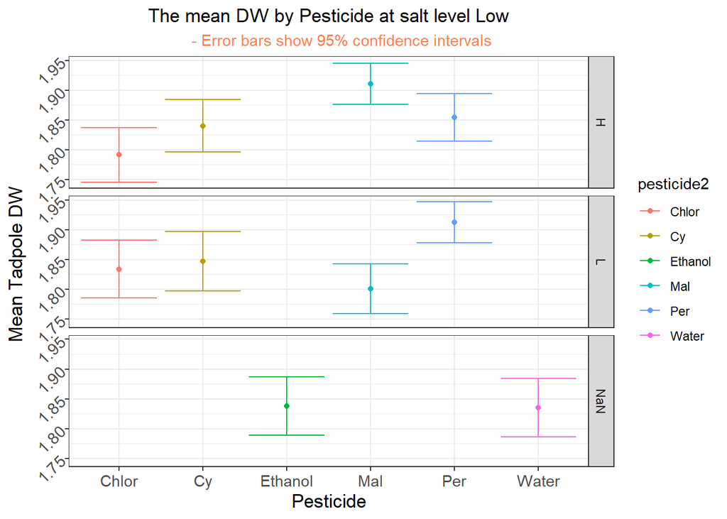

```r
DW_exp2 = Exp2_SaltL%>%
  group_by(pesticidecon,pesticide2)%>%
  summarise(count = n(),  #  calculate count, mean, and sd in each group
             mean = mean(dw,na.rm=TRUE),
             std_dev = sd(dw,na.rm =TRUE ))%>%
   mutate(std_error = std_dev / sqrt(count),  #  add standard error of each mean
         lower = mean - 1.96 * std_error,  #  compute lower bound
          upper = mean + 1.96 * std_error)


ggplot(DW_exp2,aes(x=pesticide2,y=mean,col=pesticide2))+
  geom_point()+
  geom_errorbar(aes(ymin = lower,
                    ymax=upper))+
  labs(x="Pesticide",
       y="Mean Tadpole DW ",
       title = "The mean DW by Pesticide at salt level Low",
       subtitle = "      - Error bars show 95% confidence intervals")+
  my_theme+
  facet_grid(pesticidecon~.)
```

```r
DW_exp2 = Exp2_SaltN%>%
  group_by(pesticidecon,pesticide2)%>%
  summarise(count = n(),  #  calculate count, mean, and sd in each group
             mean = mean(dw,na.rm=TRUE),
             std_dev = sd(dw,na.rm =TRUE ))%>%
   mutate(std_error = std_dev / sqrt(count),  #  add standard error of each mean
         lower = mean - 1.96 * std_error,  #  compute lower bound
          upper = mean + 1.96 * std_error)
```

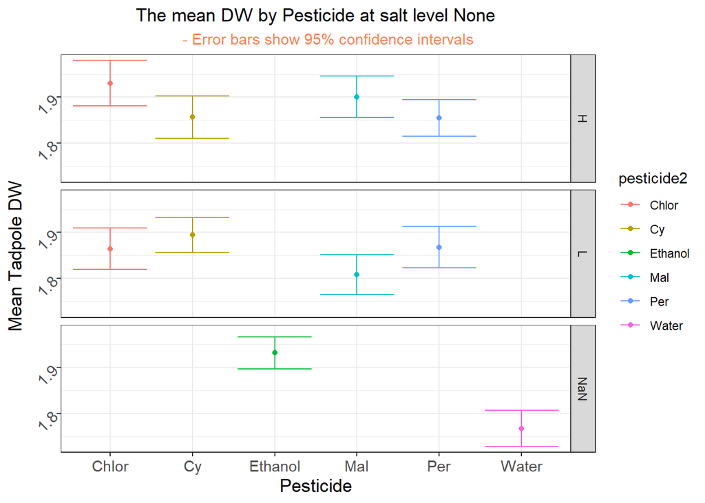

```r
ggplot(DW_exp2,aes(x=pesticide2,y=mean,col=pesticide2))+
  geom_point()+
  geom_errorbar(aes(ymin = lower,
                    ymax=upper))+
  labs(x="Pesticide",
       y="Mean Tadpole DW ",
       title = "The mean DW by Pesticide at salt level None",
       subtitle = "      - Error bars show 95% confidence intervals")+
  my_theme+
  facet_grid(pesticidecon~.)
```

### Three way ANOVA for DL

```r
experiment2%>%
  anova_test(dl~pesticide2 * pesticidecon*salt)
```

```
## ANOVA Table (type II tests)
##
##                         Effect DFn DFd      F        p p<.05      ges
## 1                   pesticide2   4 996  2.883 2.20e-02     * 0.011000
## 2                 pesticidecon   1 996 10.742 1.00e-03     * 0.011000
## 3                         salt   2 996  3.770 2.30e-02     * 0.008000
## 4      pesticide2:pesticidecon   3 996 10.508 8.30e-07     * 0.031000
## 5              pesticide2:salt   8 996  2.036 4.00e-02     * 0.016000
## 6            pesticidecon:salt   2 996  0.254 7.76e-01       0.000509
## 7 pesticide2:pesticidecon:salt   6 996  1.882 8.10e-02       0.011000
```

Interaction is not significant

```r
experiment2%>%
  group_by(salt)%>%
  anova_test(dl~pesticide2*pesticidecon)%>%
  pander()
```

| salt | Effect | DFn | DFd | F | p | p<.05 | ges |
| --- | --- | --- | --- | --- | --- | --- | --- |
| H | pesticide2 | 4 | 350 | 5.166 | 0.00047 | * | 0.056 |
| H | pesticidecon | 1 | 350 | 2.581 | 0.109 |  | 0.007 |
| H | pesticide2:pesticidecon | 3 | 350 | 6.037 | 0.000511 | * | 0.049 |
| L | pesticide2 | 4 | 341 | 0.235 | 0.919 |  | 0.003 |
| L | pesticidecon | 1 | 341 | 2.458 | 0.118 |  | 0.007 |
| L | pesticide2:pesticidecon | 3 | 341 | 5.2 | 0.002 | * | 0.044 |
| N | pesticide2 | 4 | 305 | 2.749 | 0.028 | * | 0.035 |
| N | pesticidecon | 1 | 305 | 6.795 | 0.01 | * | 0.022 |
| N | pesticide2:pesticidecon | 3 | 305 | 2.924 | 0.034 | * | 0.028 |

This chunk performed a Two way ANOVA on pesticide category in terms of mean DL by each salt level.

```r
Tukey_SL = experiment2%>%
  group_by(salt,pesticidecon)%>%
  tukey_hsd(dw~pesticide2)

Tukey_SL[which(Tukey_SL$p.adj<=0.05),]%>%
  pander()
```

Table continues below

| pesticidecon | salt | term | group1 | group2 | estimate | conf.low |
| --- | --- | --- | --- | --- | --- | --- |
| H | H | pesticide2 | Mal | Per | 0.1048 | 0.02267 |
| H | L | pesticide2 | Chlor | Mal | 0.1193 | 0.03133 |
| L | L | pesticide2 | Mal | Per | 0.1118 | 0.02941 |
| NaN | N | pesticide2 | Ethanol | Water | -0.1647 | -0.2287 |

| conf.high | p.adj | p.adj.signif |
| --- | --- | --- |
| 0.187 | 0.00625 | ** |
| 0.2074 | 0.00318 | ** |
| 0.1942 | 0.00317 | ** |
| -0.1006 | 3.74e-06 | **** |

This chunk performed a Tukey-test on pesticide category in terms of mean DW by each concentration level and salt level. The pairs with p-value <= 0.05 are shown. (I did not write down the ANOVA test because a non-empty result from tukey test implies a statistically significant result in the one way ANOVA test)

### Visualization

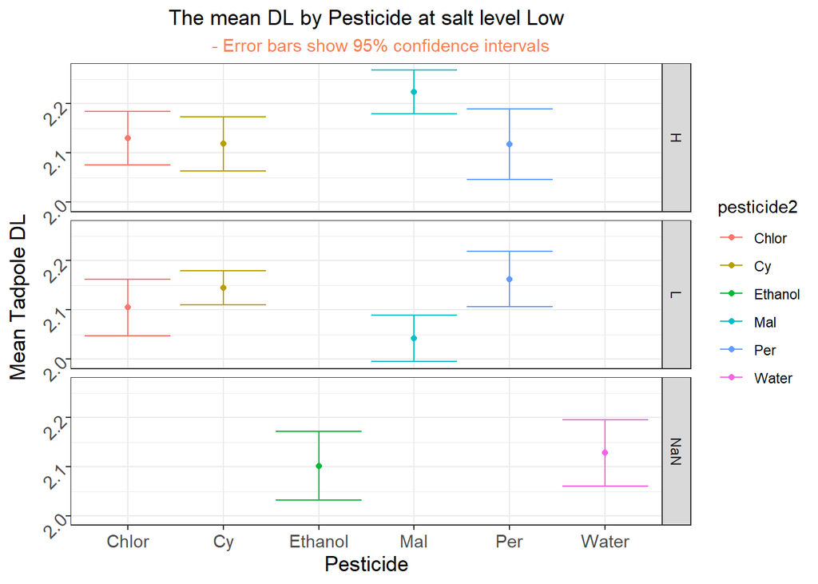

```r
DL_exp2 = Exp2_SaltL%>%
  group_by(pesticidecon,pesticide2)%>%
  summarise(count = n(),  #  calculate count, mean, and sd in each group
             mean = mean(dl,na.rm=TRUE),
             std_dev = sd(dl,na.rm =TRUE ))%>%
   mutate(std_error = std_dev / sqrt(count),  #  add standard error of each mean
         lower = mean - 1.96 * std_error,  #  compute lower bound
          upper = mean + 1.96 * std_error)


ggplot(DL_exp2,aes(x=pesticide2,y=mean,col=pesticide2))+
  geom_point()+
  geom_errorbar(aes(ymin = lower,
                    ymax=upper))+
  labs(x="Pesticide",
       y="Mean Tadpole DL ",
       title = "The mean DL by Pesticide at salt level Low",
       subtitle = "      - Error bars show 95% confidence intervals")+
  my_theme+
  facet_grid(pesticidecon~.)
```

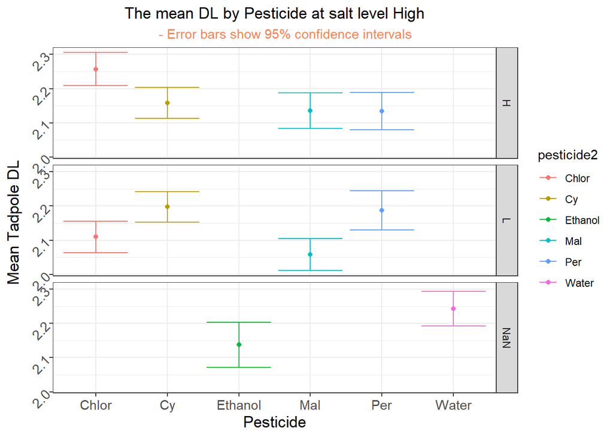

```r
DL_exp2 = Exp2_SaltH%>%
  group_by(pesticidecon,pesticide2)%>%
  summarise(count = n(),  #  calculate count, mean, and sd in each group
             mean = mean(dl,na.rm=TRUE),
             std_dev = sd(dl,na.rm =TRUE ))%>%
   mutate(std_error = std_dev / sqrt(count),  #  add standard error of each mean
         lower = mean - 1.96 * std_error,  #  compute lower bound
          upper = mean + 1.96 * std_error)


ggplot(DL_exp2,aes(x=pesticide2,y=mean,col=pesticide2))+
  geom_point()+
  geom_errorbar(aes(ymin = lower,
                    ymax=upper))+
  labs(x="Pesticide",
       y="Mean Tadpole DL ",
       title = "The mean DL by Pesticide at salt level High",
       subtitle = "      - Error bars show 95% confidence intervals")+
  my_theme+
  facet_grid(pesticidecon~.)
```

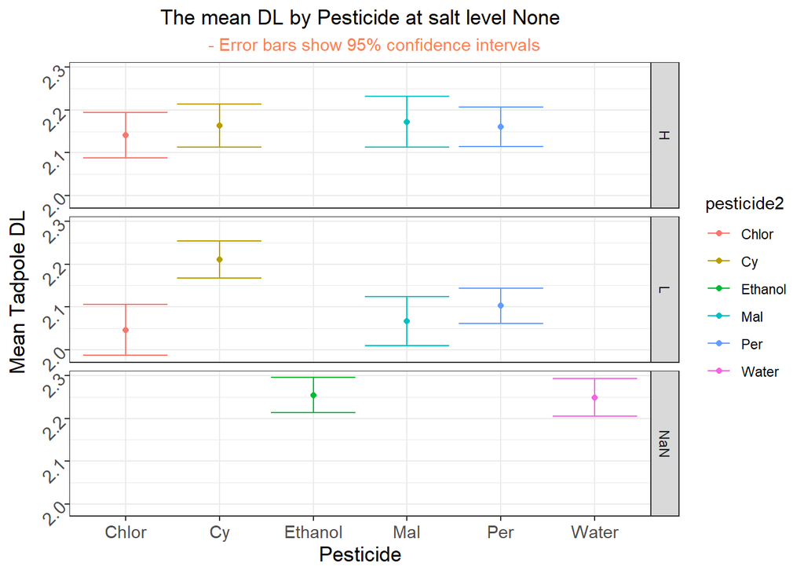

```r
DL_exp2 = Exp2_SaltN%>%
  group_by(pesticidecon,pesticide2)%>%
  summarise(count = n(),  #  calculate count, mean, and sd in each group
             mean = mean(dl,na.rm=TRUE),
             std_dev = sd(dl,na.rm =TRUE ))%>%
   mutate(std_error = std_dev / sqrt(count),  #  add standard error of each mean
         lower = mean - 1.96 * std_error,  #  compute lower bound
          upper = mean + 1.96 * std_error)


ggplot(DL_exp2,aes(x=pesticide2,y=mean,col=pesticide2))+
  geom_point()+
  geom_errorbar(aes(ymin = lower,
                    ymax=upper))+
  labs(x="Pesticide",
       y="Mean Tadpole DL ",
       title = "The mean DL by Pesticide at salt level None",
       subtitle = "      - Error bars show 95% confidence intervals")+
  my_theme+
  facet_grid(pesticidecon~.)
```

Conclusion:

By adding salt, ethanol and water generally did not have significant difference on brain measurement

The effect of pesticides vary across different level of salt, and concentration for different brain dimension.

# Mixed Effect Model

## Mesocosm Exp1

```r
exp1_mixed = lmer(bodymass~pesticide2*pesticidecon+(1|mesocosm),data = na.omit(experiment1),REML=FALSE)

exp1_model = lm(bodymass~pesticide2*pesticidecon,data = na.omit(experiment1))

anova(exp1_mixed,exp1_model)%>%
  pander()
```

Data: na.omit(experiment1)

|  | npar | AIC | BIC | logLik | deviance | Chisq | Df | Pr(>Chisq) |
| --- | --- | --- | --- | --- | --- | --- | --- | --- |
| **exp1_model** | 15 | 632.2 | 693.4 | -301.1 | 602.2 | NA | NA | NA |
| **exp1_mixed** | 16 | 632.2 | 697.5 | -300.1 | 600.2 | 1.957 | 1 | 0.1619 |

This chunk builds a mesocosm mixed effect model and a simple regression model of the terms we used in experiment 1 and compared two models by ANOVA test.

- There is no statistically significant difference between the two models, and we do not need to include the random effect of mesocosm in experiment 1.

## Person Exp1

```r
exp1_mixed = lmer(bodymass~pesticide2*pesticidecon+(1|person),data = na.omit(experiment1),REML=FALSE)

exp1_model = lm(bodymass~pesticide2*pesticidecon,data = na.omit(experiment1))

anova(exp1_mixed,exp1_model)%>%
  pander()
```

Data: na.omit(experiment1)

|  | npar | AIC | BIC | logLik | deviance | Chisq | Df | Pr(>Chisq) |
| --- | --- | --- | --- | --- | --- | --- | --- | --- |
| **exp1_model** | 15 | 632.2 | 693.4 | -301.1 | 602.2 | NA | NA | NA |
| **exp1_mixed** | 16 | 634.2 | 699.5 | -301.1 | 602.2 | 0 | 1 | 1 |

This chunk builds a person mixed effect model and a simple regression model of the terms we used in experiment 1 and compared two models by ANOVA test.

- There is no statistically significant difference between the two models, and we do not need to include the random effect of person in experiment 1.

## Mesocosm Exp2

```r
exp2_mixed = lmer(bodymass ~ pesticide2 * pesticidecon * salt+(1|mesocosm),
                  data = na.omit(experiment2),REML = FALSE)
exp2_model = lm(bodymass ~ pesticide2 * pesticidecon * salt,
                data = na.omit(experiment2))
anova(exp2_mixed,exp2_model)%>%
  pander()
```

Data: na.omit(experiment2) This chunk builds a mesocosm mixed effect model and a simple regression model of the terms we used in experiment 2 and compared two models by ANOVA test.

|  | npar | AIC | BIC | logLik | deviance | Chisq | Df | Pr(>Chisq) |
| --- | --- | --- | --- | --- | --- | --- | --- | --- |
| **exp2_model** | 31 | 1580 | 1732 | -758.8 | 1518 | NA | NA | NA |
| **exp2_mixed** | 32 | 1577 | 1734 | -756.3 | 1513 | 5.139 | 1 | 0.02339 |

- There is statistically significant difference between the two models, and we may need to include the random effect of mesocosm in experiment 2.

## Person Exp2

```r
exp2_mixed = lmer(bodymass ~ pesticide2 * pesticidecon * salt+(1|person),
                  data = na.omit(experiment2),REML = FALSE)
```

```
## fixed-effect model matrix is rank deficient so dropping 24 columns / coefficients
```

```
## boundary (singular) fit: see ?isSingular
```

```r
exp2_model = lm(bodymass ~ pesticide2 * pesticidecon * salt,
                data = na.omit(experiment2))
anova(exp2_mixed,exp2_model)%>%
  pander()
```

Data: na.omit(experiment2)

|  | npar | AIC | BIC | logLik | deviance | Chisq | Df | Pr(>Chisq) |
| --- | --- | --- | --- | --- | --- | --- | --- | --- |
| **exp2_model** | 31 | 1580 | 1732 | -758.8 | 1518 | NA | NA | NA |
| **exp2_mixed** | 32 | 1582 | 1739 | -758.8 | 1518 | 0 | 1 | 1 |

This chunk builds a person mixed effect model and a simple regression model of the terms we used in experiment 2 and compared two models by ANOVA test.

## Conclusion

Only the random effect of Mesocosm on experiment 2 is significant, but we believe that the effect is negligible.